# Prediction Assignment - Weight Lifting Exercise

Haoran Shi

31/05/2021

# Data and Exploratory Analysis

*Ugulino et al.* researched on quantify how much of a particular activity they do, but they rarely quantify how well they do it. Using devices such as Jawbone Up, Nike FuelBand, and Fitbit it is now possible to collect a large amount of data about personal activity relatively inexpensively. These type of devices are part of the quantified self movement – a group of enthusiasts who take measurements about themselves regularly to improve their health, to find patterns in their behavior, or because they are tech geeks. One thing that people regularly do is quantify how much of a particular activity they do, but they rarely quantify how well they do it. In this project, your goal will be to use data from accelerometers on the belt, forearm, arm, and dumbell of 6 participants. They were asked to perform barbell lifts correctly and incorrectly in 5 different ways. More information is available on the [Weight Lifting Exercise Dataset](http://web.archive.org/web/20161224072740/http:/groupware.les.inf.puc-rio.br/har).

We first load the libraries needed for the analysis and datasets. We will also patition the training data into training and testing set.

```r
library(tidyverse)
library(caret)
library(randomForest)
library(rpart)
library(rpart.plot)
library(corrplot)

har <- "http://d396qusza40orc.cloudfront.net/predmachlearn/pml-training.csv"
test.url  <- "http://d396qusza40orc.cloudfront.net/predmachlearn/pml-testing.csv"

har.data <- read.csv(url(har))
final.test <- read.csv(url(test.url))

set.seed(0)

training.index <- createDataPartition(har.data$classe, p = 0.60,list=FALSE)
train <- har.data[training.index,]
test <- har.data[-training.index,]
```

After a quick glance of the data, it seems like the first five variables are identifiers for the participants, which should not be included in the model. Also I’d like to remove the variables that are mostly NA’s or have little variances in the training set.

```r
train.set <- train[,-(1:5)]
var.na <- sapply(train.set, function(x) mean(is.na(x))) > 0.90
train.set <- train.set[,var.na==FALSE]

nzv <- nearZeroVar(train.set)
train.set <- train.set[,-nzv]
```

After removing the variables that provided little information for the prediction exercise, 54 variables will be included in designing the machine learning algorithm.

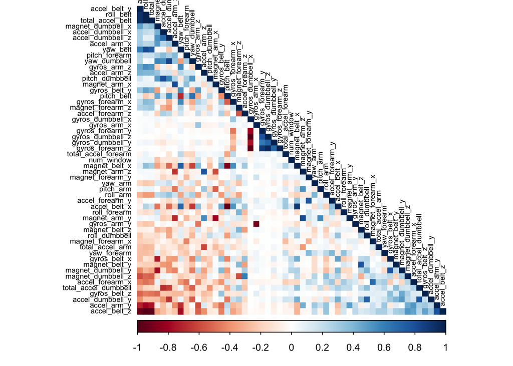

```r
cor.matrix <- cor(train.set[,-54])
corrplot(cor.matrix, order = "FPC", method = "color", type = "lower",
         tl.cex = 0.6, tl.col = 'black')
```

The correlation plot shows that there are some correlation between predicting variables; however, the correlations are not significant enough to warrant the use pre-processing methods such as principle component analysis.

# Prediction Models

The variable of interest **classe** is a categorical variable, thus classification models will be used. I’ll build two models on the training data set, namely 1) Random Forest; 2) Stochastic Gradient Boosting. The final model will be chosen based on the accuracy on the testing set using confusion matrix. Cross validation will be used, and for this exercise, repeated k-fold cross validation, where $k=3, will be used due to the limitation of computing power.

## Random Forest

```r
fit.control <- trainControl(method = "repeatedcv",
                            number = 3,
                            repeats = 3)
set.seed(1)
har.rf <- train(classe~., data = train.set,
                method = "rf", trControl = fit.control)
pred.rf <- predict(har.rf,test)
confusionMatrix(pred.rf,as.factor(test$classe))
```

```
## Confusion Matrix and Statistics
##
##           Reference
## Prediction    A    B    C    D    E
##          A 2232    1    0    0    0
##          B    0 1512    4    0    1
##          C    0    4 1364    6    0
##          D    0    1    0 1280    4
##          E    0    0    0    0 1437
##
## Overall Statistics
##
##                Accuracy : 0.9973
##                  95% CI : (0.9959, 0.9983)
##     No Information Rate : 0.2845
##     P-Value [Acc > NIR] : < 2.2e-16
##
##                   Kappa : 0.9966
##
##  Mcnemar's Test P-Value : NA
##
## Statistics by Class:
##
##                      Class: A Class: B Class: C Class: D Class: E
## Sensitivity            1.0000   0.9960   0.9971   0.9953   0.9965
## Specificity            0.9998   0.9992   0.9985   0.9992   1.0000
## Pos Pred Value         0.9996   0.9967   0.9927   0.9961   1.0000
## Neg Pred Value         1.0000   0.9991   0.9994   0.9991   0.9992
## Prevalence             0.2845   0.1935   0.1744   0.1639   0.1838
## Detection Rate         0.2845   0.1927   0.1738   0.1631   0.1832
## Detection Prevalence   0.2846   0.1933   0.1751   0.1638   0.1832
## Balanced Accuracy      0.9999   0.9976   0.9978   0.9973   0.9983
```

## Boosting

```r
set.seed(2)
har.gbm <- train(classe~., data = train.set,
                 method = "gbm", trControl = fit.control,
                 verbose = FALSE)
pred.gbm <- predict(har.gbm,test)
confusionMatrix(pred.gbm,as.factor(test$classe))
```

```
## Confusion Matrix and Statistics
##
##           Reference
## Prediction    A    B    C    D    E
##          A 2225    3    0    0    1
##          B    7 1498   13    4    8
##          C    0   17 1349   18    2
##          D    0    0    5 1263   10
##          E    0    0    1    1 1421
##
## Overall Statistics
##
##                Accuracy : 0.9885
##                  95% CI : (0.9859, 0.9908)
##     No Information Rate : 0.2845
##     P-Value [Acc > NIR] : < 2.2e-16
##
##                   Kappa : 0.9855
##
##  Mcnemar's Test P-Value : NA
##
## Statistics by Class:
##
##                      Class: A Class: B Class: C Class: D Class: E
## Sensitivity            0.9969   0.9868   0.9861   0.9821   0.9854
## Specificity            0.9993   0.9949   0.9943   0.9977   0.9997
## Pos Pred Value         0.9982   0.9791   0.9733   0.9883   0.9986
## Neg Pred Value         0.9988   0.9968   0.9971   0.9965   0.9967
## Prevalence             0.2845   0.1935   0.1744   0.1639   0.1838
## Detection Rate         0.2836   0.1909   0.1719   0.1610   0.1811
## Detection Prevalence   0.2841   0.1950   0.1767   0.1629   0.1814
## Balanced Accuracy      0.9981   0.9909   0.9902   0.9899   0.9926
```

## Model Comparison

Both models do a very good job based on accuracy on testing set, as both of them are close to 99%. However, the random forest model performs slightly better, which will be used for the final quiz.

The prediction of the quiz data using both models is shown below - not surprisingly, they yeild the same predictions.

```r
predict(har.rf,final.test)
```

```
##  [1] B A B A A E D B A A B C B A E E A B B B
## Levels: A B C D E
```

```r
predict(har.gbm,final.test)
```

```
##  [1] B A B A A E D B A A B C B A E E A B B B
## Levels: A B C D E
```